# Stock Trading App Tutorial Part 1-3

## Part 1: [Database design](https://www.youtube.com/watch?v=XyvsiZsUetU&list=PLvzuUVysUFOuoRna8KhschkVVUo2E2g6G&index=2)

Retrieving historical data prices through `yfinance` into `.csv` file:

```
import yfinance
df = yfinance.download("AAPL", start="2020-01-01", end="2020-10-02")
df.to_csv("AAPL.csv")
```

### SQL database vs CSV file

- Ease of management:
  - Will need to keep track of small, frequent changes (e.g. Price history of thousands of stocks, stock symbols change), read large numbers of files separated by categories just to access all relevant info, e.t.c.
  - Would be easier to store data and their relationships in SQL database through SQLite.
- Expandability: New key characteristics -> New column easier to add in SQL.
- Entity relationships: Relational database allows linking of price records, watchlists, trades in separate tables that reference central stock symbol table; eliminates redundancy.
- Indexing and aggregation: SQL has functionality to specifically return only data of interest.

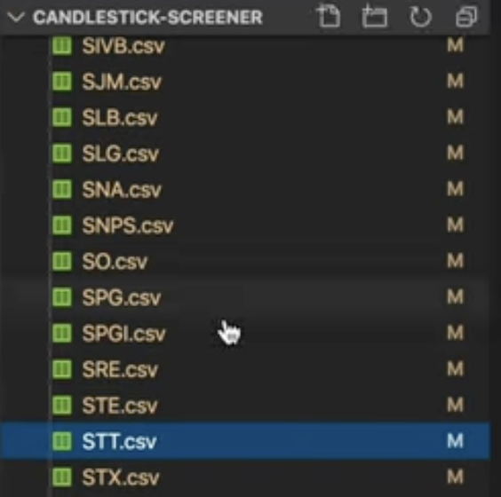

### SQLite

Simple tutorial for storing stock symbols and their associated price histories

- Download SQLite command line executable: https://www.sqlite.org/download.html
- Go to directory of interest.
- `sqlite3 __` to open database `__` in SQL; will be created if it did not exist.

```
sqlite3 app.db
```

- Create new table within `sqlite` named "stock" with `id`, `symbol` and `company`.
  - `id` is primary key
  - `symbol` and `company` are required and are text

```
CREATE TABLE IF NOT EXISTS stock (
    id INTEGER PRIMARY KEY,
    symbol TEXT NOT NULL UNIQUE,
    company TEXT NOT NULL
);
```

- Exit with `.quit`.

### Desired database diagram

Attributes and record of each row, unique keys as identifiers within table, foreign keys to reference data in other tables.

- STOCK
  - ID: PRIMARY KEY
  - SYMBOL: TEXT
  - COMPANY: TEXT
- STOCK_PRICE (To contain corresponding stock prices)
  - ID: PRIMARY KEY
  - STOCK_ID: FOREIGN KEY
  - DATE
  - OPEN
  - HIGH
  - LOW
  - CLOSE
  - VOLUME
- WATCHLIST
  - ID: PRIMARY KEY
  - NAME
- USER
  - ID: PRIMARY KEY
  - NAME
- Create new table within `sqlite` named "stock_price".

```
CREATE TABLE IF NOT EXISTS stock_price (
    id INTEGER PRIMARY KEY,
    stock_id INTEGER,
    date NOT NULL,
    open NOT NULL,
    high NOT NULL,
    low NOT NULL,
    close NOT NULL,
    adjusted_close NOT NULL,
    volume NOT NULL,
    FOREIGN KEY (stock_id) REFERENCES stock (id)
);
```

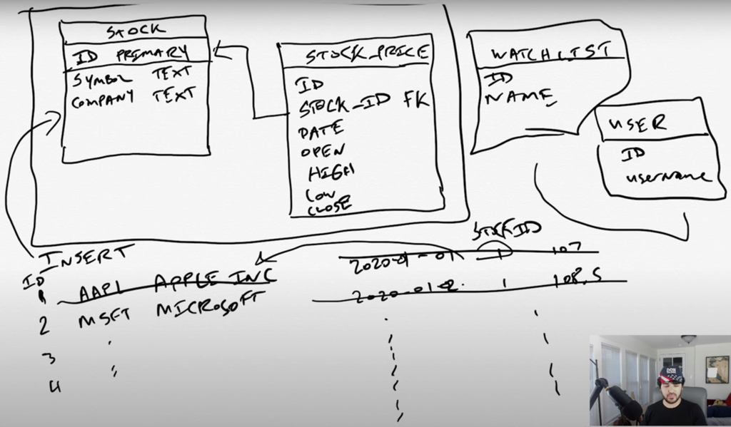

## Part 2: [SQL Create, Read, Update, Delete (CRUD)](https://www.youtube.com/watch?v=NaIv42VVxa8&list=PLvzuUVysUFOuoRna8KhschkVVUo2E2g6G&index=3)

Reconnect with `sqlite3 app.db` first.

### Example: Twitter/X

- Creating tweet owned by user account, which has comments referencing tweet, e.t.c
- Reading tweets on UI, selecting which ones to read more thoroughly
- Delete tweets
- Edit profile (Not tweets)

### INSERT

- Create records in database.
- Statement creates 4 rows with combinations of `symbol` and `company`.
- `id` for each item in `stock` will be automatically assigned by SQL upon creation.

```
INSERT INTO stock (symbol, company) VALUES ('AAPL', 'Apple');
INSERT INTO stock (symbol, company) VALUES ('MSFT', 'Microsoft');
INSERT INTO stock (symbol, company) VALUES ('TSLA', 'Tesla');
INSERT INTO stock (symbol, company) VALUES ('AMD', 'Advanced Micro Devices');
```

### SELECT

- Retrieve records from database tables.

```
SELECT * FROM stock;
-- 1|AAPL|Apple
-- 2|MSFT|Microsoft
-- 3|TSLA|Tesla
-- 4|AMD|Advanced Micro Devices
```

- `*` to select all columns in table.
- Specify columns between `SELECT` and `FROM`.

```
SELECT id, symbol FROM stock;
-- 1|AAPL
-- 4|AMD
-- 2|MSFT
-- 3|TSLA
```

- Some ways to narrow down data:
  - `WHERE bool`: Only rows that meet `bool`
  - `LIMIT n`: Only show first n results
  - `LIKE`
  - `ORDER BY __`
  - `COUNT(_)`

```
SELECT company FROM stock WHERE symbol = 'TSLA';
-- Tesla

SELECT * FROM stock LIMIT 3;
-- 1|AAPL|Apple
-- 2|MSFT|Microsoft
-- 3|TSLA|Tesla

SELECT symbol FROM stock WHERE id = '2';
-- MSFT

SELECT * FROM stock WHERE company LIKE '%icro%';
-- 2|MSFT|Microsoft
-- 4|AMD|Advanced Micro Devices

SELECT * FROM stock ORDER BY company DESC;
-- 3|TSLA|Tesla
-- 2|MSFT|Microsoft
-- 1|AAPL|Apple
-- 4|AMD|Advanced Micro Devices

SELECT COUNT(*) FROM stock;
-- 4
```

### UPDATE

- Update selected record(s) in database table.
- Need to clarify which records are to be updated.

[output not shown]

### DELETE

- Delete selected record(s) in database table.
- When creating tables, should also specify how SQLite should clean up references to deleted stocks.
- If symbol deleted from stock table, should delete all price records of stock.

```
DELETE FROM stock where id = 3;
SELECT * FROM stock;
-- 1|AAPL|Apple Inc.
-- 2|MSFT|Microsoft
-- 4|AMD|Advanced Micro Devices
```

## Part 3: [Python, SQL and Stock Universes](https://www.youtube.com/watch?v=bZwDyULs13M&list=PLvzuUVysUFOuoRna8KhschkVVUo2E2g6G&index=5)

- Want to:
  - Insert hundreds of stock symbols
  - Track thousands of price history records for each symbol
  - Display data on web browser
  - Do technical analysis
  - Automatically execute trades
- Use `sqlite3` module (Already built in) to connect to database to execute queries.
  - Call .connect() and give name of database.
  - If database did not exist already, will be created, otherwise will access existing version.

```
import sqlite3
connection = sqlite3.connect("app.db") # Connect to database
```

- If database and their tables did not exist already, will have to use the following code from `create_db.py` to create them.
  - `cursor()` method to execute SQL statements.
  - `commit()` method to commit changes; if exception is thrown, will roll back to before without intermediate changes.

```
import sqlite3
connection = sqlite3.connect("app.db") # Connect to database
cursor = connection.cursor() # To execute SQL statements

cursor.executescript("""
    CREATE TABLE IF NOT EXISTS stock (
        id INTEGER PRIMARY KEY,
        symbol TEXT NOT NULL UNIQUE,
        company TEXT NOT NULL
    );
    CREATE TABLE IF NOT EXISTS stock_price (
        id INTEGER PRIMARY KEY,
        stock_id INTEGER,
        date NOT NULL,
        open NOT NULL,
        high NOT NULL,
        low NOT NULL,
        close NOT NULL,
        adjusted_close NOT NULL,
        volume NOT NULL,
        FOREIGN KEY (stock_id) REFERENCES stock (id)
    );
""")
connection.commit() # To commit changes to databases
```

### Database cursors

- As stated before, `cursor()` used to execute SQL statements.
- `populate_db.py` to fill database with corresponding data.
  - If something went wrong during the program, can roll back changes and throw them away with `rollbacl()`

```
import sqlite3
connection = sqlite3.connect("app.db") # Connect to database
cursor = connection.cursor() # To execute SQL statements

cursor.executescript("""
    INSERT INTO stock (symbol, company) VALUES ('ADBE', 'Adobe Inc.');
    INSERT INTO stock (symbol, company) VALUES ('VZ', 'Verizon');
    INSERT INTO stock (symbol, company) VALUES ('Z', 'Zillow');
""")
connection.commit() # To commit changes to databases
```

- Delete all records before populating it with complete list of stock values.

```
import sqlite3
connection = sqlite3.connect("app.db") # Connect to database
cursor = connection.cursor() # To execute SQL statements

cursor.execute("DELETE FROM stock")
connection.commit() # To commit changes to databases
```

### Tradable stock universe

Options to access stock lists:

- NASDAQ FTP site: Will require downloading text files, parsing them, merging them, then run SQL INSERT for each stock in file.
- [alpaca_trade_api](https://github.com/alpacahq/alpaca-trade-api-python)
  - Will need to generate new keys `insert_api_key_id` and `insert_api_secret` for each use: https://app.alpaca.markets/paper/dashboard/overview
  - https://paper-api.alpaca.markets used as URL to access paper trading account; use https://api.alpaca.markets to access live trading account.

```
pip3 install alpaca_trade_api
```

```
# Establish sqlite3 connection and cursor
import sqlite3
import alpaca_trade_api as tradeapi
connection = sqlite3.connect("app.db") # Connect to database
cursor = connection.cursor() # To execute SQL statements

api = tradeapi.REST("insert_api_key_id", "insert_api_secret", base_url = "https://paper-api.alpaca.markets") # Replace insert_api_key_id and insert_api_secret
assets = api.list_assets()
for asset in assets:
    print(asset)

connection.commit() # To commit changes to databases
```

- [Alpha Vantage](https://www.alphavantage.co/documentation/): 25 requests per day for free.

```
pip3 install alpha-vantage
```

### Enter new data into database (populate_db.py)

- alpaca_trade_api: Attribute `__` can be accessed with `asset.__`
  - `id`: Internal identifier
  - `name`
  - `shortable`
  - `symbol`
  - `status`
  - `tradable`
- `for` loop to repeatedly `INSERT` data into database.
- `?` in `execute()` acts as variable.
- Need to handle errors from third party sources.
  - e.g. `asset.symbol == "VXX"` has 2 cases, with one active and another inactive, but otherwise both are identical.
  - In this case, `asset.status == "active"`.

```
# # Establish sqlite3 connection and cursor
# ___

api = tradeapi.REST("insert_api_key_id", "insert_api_secret", base_url = "https://paper-api.alpaca.markets") # Replace insert_api_key_id and insert_api_secret
assets = api.list_assets() # Return list of symbols
for asset in assets:
    # print(asset)
    try:
        if asset.status == "active" and asset.tradable: # To avoid overlaps with inactive ones; want only info of interest
            cursor.execute("INSERT INTO stock (symbol, company) VALUES (?, ?)", (asset.symbol, asset.name))
    except Exception as e:
        print(asset.symbol) # symbol was set to be unique
        print(e)

connection.commit() # To commit changes to databases
```